# Projeto de Disciplina de Processamento de Linguagem Natural com Python

Bem-vindo ao projeto de disciplina de **Processamento de Linguagem Natural com Python**. Ao longo das últimas aulas vimos uma série de aplicações que nos deram a amplitude de possibilidades em trabalhar com textos. Para tal, usamos diversas bibliotecas, onde as que mais se destacaram foram NLTK, SPACY e GENSIM.

Esse notebook servirá de guia para a execução de uma análise de tópicos completa, usando o algoritmo de LDA e recursos para interpretação dos resultados. Utilizaremos notícias da seção "Mercado" extraídas da Folha de S. Paulo no ano de 2016. Complete a análise com os códigos que achar pertinente e responda as questões presentes no Moodle. Boa sorte!

## O Notebook

Nesse notebook, você será guiado pela análise de **Extração de Tópicos**. As seguintes tarefas serão realizadas

1. Download dos dados provenientes do kaggle
2. Seleção dos dados relevantes para a nossa análise
3. Instalação das principais ferramentas e importação de módulos
4. Pré-processamento usando NLTK
5. Pré-processamento usando Spacy
6. Análise de tópicos usando LDA
7. Análise de NER usando Spacy
8. Visualização dos tópicos usando tokens e entidades.

## Instruções para baixar os dados

Para baixar os dados será necessário o uso do gerenciador de downloads da Kaggle. A Kaggle, uma subsidiária do grupo Alphabet (Google), é uma comunidade on-line de cientistas de dados e profissionais de aprendizado de máquina.

Para utilizar o gerenciador, será necessário criar uma conta no site Kaggle.com. Com a conta criada, obtenha um token de acesso, no formato kaggle.json

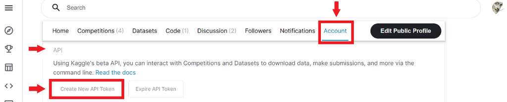

Em posse do token (baixe para seu computador), execute a células da próxima seção para acessar os dados de interesse e baixá-los.

# Baixe os dados

Instale o gerenciador kaggle no ambiente do Colab e faça o upload do arquivo kaggle.json

```python
##!pip install kaggle
##!rm -rf kaggle.json
##from google.colab import files

files.upload()
```

Crie a pasta .kaggle

```python
##!rm -rf .kaggle
##!mkdir .kaggle
##!cp kaggle.json .kaggle/
##!chmod 600 .kaggle/kaggle.json
```

Baixe o dataset

```python
##!kaggle datasets download --force -d marlesson/news-of-the-site-folhauol
```

## Criar o DataFrame com os dados lidos diretamente da plataforma Kaggle

```python
import zipfile
import pandas as pd
from tqdm.auto import tqdm
tqdm.pandas()


df = pd.read_csv("news-of-the-site-folhauol.zip")
```

# Atualizar o SPACY e instalar os modelos pt_core_news_lg

```python
import sys

!{sys.executable} -m spacy download pt_core_news_lg

import spacy
from spacy.lang.pt.stop_words import STOP_WORDS
```

[output not shown]

[output cut: 18 more lines]

[output not shown]

## Instalar os datasets `stopwords`, `punkt` e `rslp` do nltk

```python
import nltk

# Escreva seu código aqui
nltk.download('stopwords')
nltk.download('punkt')
nltk.download('rslp')
nltk.download('punkt_tab')
```

```
True
```

## Carregar os módulos usados ao longo desse notebook

```python
##%pip install pyldavis &> /dev/null

import warnings
warnings.filterwarnings('ignore')

from sklearn.feature_extraction.text import TfidfVectorizer
from sklearn.decomposition import LatentDirichletAllocation as LDA
import numpy as np

from wordcloud import WordCloud

import seaborn as sns
import matplotlib.pyplot as plt
from itertools import chain

from typing import List, Set, Any


SEED = 123
```

# Filtrando os dados para utilizar apenas as notícias do ano de 2016 e da categoria "Mercado"

Filtre os dados do DataFrame df e crie um DataFrame news_2016 que contenha apenas notícias de **2016** e da categoria **mercado**.

```python
news_2016 = df[
    (df['date'].dt.year == 2016) &
    (df['category'].str.lower() == 'mercado')
]
news_2016
```

|  | title | text | date | category | subcategory | link |
| --- | --- | --- | --- | --- | --- | --- |
| 34207 | Fazendeira cria própria rede de banda larga e ... | "Sou apenas a mulher de um fazendeiro", diz Ch... | 2016-12-31 | mercado | NaN | http://www1.folha.uol.com.br/mercado/2016/12/1... |
| 34238 | Alteração na cobrança do ICMS eleva conta de c... | A conta do celular pós-pago ou controle ficará... | 2016-12-31 | mercado | NaN | http://www1.folha.uol.com.br/mercado/2016/12/1... |
| 34245 | Ajustes sobre servidores públicos emperram nos... | A maior parte dos projetos de ajuste das conta... | 2016-12-31 | mercado | NaN | http://www1.folha.uol.com.br/mercado/2016/12/1... |
| 34248 | Inventor da internet das coisas ataca mitos so... | Desde as primeiras décadas do século 19 se diz... | 2016-12-31 | mercado | NaN | http://www1.folha.uol.com.br/mercado/2016/12/1... |
| 34249 | Livro analisa empresas de crescimento exponenc... | O Cifras & Letras seleciona semanalmente lança... | 2016-12-31 | mercado | NaN | http://www1.folha.uol.com.br/mercado/2016/12/1... |
| ... | ... | ... | ... | ... | ... | ... |
| 94280 | Previsões para economia dependem de rumos do g... | Para o economista Rodolfo Margato, do banco Sa... | 2016-01-01 | mercado | NaN | http://www1.folha.uol.com.br/mercado/2016/01/1... |
| 94295 | Repelentes e água de coco lideram a lista de s... | Conveniência, saúde, boa forma e prazer. As te... | 2016-01-01 | mercado | NaN | http://www1.folha.uol.com.br/mercado/2016/01/1... |
| 94301 | Renda em queda leva mais pessoas às filas de e... | Com o rendimento em queda, mais pessoas são fo... | 2016-01-01 | mercado | NaN | http://www1.folha.uol.com.br/mercado/2016/01/1... |
| 94310 | Brasil pode perder até 2,2 milhões de vagas fo... | O Brasil pode perder até 2,2 milhões de vagas ... | 2016-01-01 | mercado | NaN | http://www1.folha.uol.com.br/mercado/2016/01/1... |
| 94314 | Usina nuclear Angra 3 procura verba e saídas p... | Enquanto briga com a falta de dinheiro em caix... | 2016-01-01 | mercado | NaN | http://www1.folha.uol.com.br/mercado/2016/01/1... |

7943 rows × 6 columns

## NLTK Tokenizer and Stemmer

Crie uma coluna no dataframe `news_2016` contendo os tokens para cada um dos textos. Os tokens devem estar representados pelo radical das palavras (stem). Para tal, complete o conteúdo da função `tokenize`.

```python
from nltk.tokenize import word_tokenize
from nltk.stem import RSLPStemmer
```

```python
def tokenize(text: str) -> List[str]:
  """
  Function for tokenizing using `nltk.tokenize.word_tokenize`

  Returns:
    - A list of stemmed tokens (`nltk.stem.RSLPStemmer`)
    IMPORTANT: Only tokens with alphabetic
               characters will be returned.
  """
  stemmer = RSLPStemmer()

  #verificação de NaN e float e converte para str
  if not isinstance(text, str):
    text = str(text)


  #tokeniza o texto
  tokens = word_tokenize(text)

  #filtra tokens alfabéticos e aplica o stemming
  stemmed_tokens = [stemmer.stem(token) for token in tokens if token.isalpha()]

  return stemmed_tokens

news_2016.loc[:, 'nltk_tokens'] = news_2016.text.progress_map(tokenize)

# verificaçao
print(news_2016["nltk_tokens"].head())
```

```
34207    [sou, apen, a, mulh, de, um, fazend, diz, chri...
34238    [a, cont, do, celul, ou, control, fic, mais, c...
34245    [a, mai, part, do, projet, de, ajust, da, cont...
34248    [desd, as, prim, déc, do, sécul, se, diz, que,...
34249    [o, cifr, letr, selec, seman, lanç, na, áre, d...
Name: nltk_tokens, dtype: object
```

## Criar uma documento SPACY para cada texto do dataset

Crie uma coluna `spacy_doc` que contenha os objetos spacy para cada texto do dataset de interesse. Para tal, carregue os modelos `pt_core_news_lg` e aplique em todos os textos (pode demorar alguns minutos...)

```python
# Carregando o modelo de processamento
nlp = spacy.load("pt_core_news_lg")

# Converter para string para evitar erros com NaN ou floats
texts = news_2016["text"].astype(str).tolist()

# Processar em lote com nlp.pipe (mais rápido que apply)
docs = list(nlp.pipe(texts, batch_size=50, n_process=4))

# Atribuir a nova coluna com os objetos spacy Doc
news_2016.loc[:, 'spacy_doc'] = docs

# Verificação
print(news_2016.head()["spacy_doc"])
```

```
34207    (", Sou, apenas, a, mulher, de, um, fazendeiro...
34238    (A, conta, do, celular, pós-pago, ou, controle...
34245    (A, maior, parte, dos, projetos, de, ajuste, d...
34248    (Desde, as, primeiras, décadas, do, século, 19...
34249    (O, Cifras, &, Letras, seleciona, semanalmente...
Name: spacy_doc, dtype: object
```

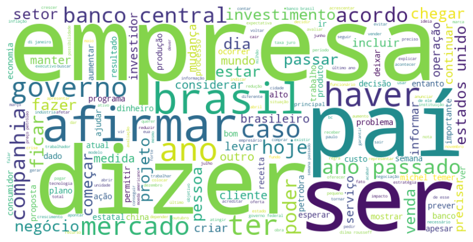

```python
import matplotlib.pyplot as plt
from wordcloud import WordCloud

all_lemmas = " ".join(
    token.lemma_.lower()
    for doc in news_2016["spacy_doc"]
    for token in doc
    if token.is_alpha and not token.is_stop
)

wordcloud = WordCloud(
    width=800,
    height=400,
    background_color='white',
    colormap='viridis'
).generate(all_lemmas)


plt.figure(figsize=(10, 5))
plt.imshow(wordcloud, interpolation='bilinear')
plt.axis("off")
plt.show()
```

## Realize a Lematização usando SPACY

O modelo NLP do spacy oferece a possiblidade de lematizar textos em português (o que não acontece com a biblioteca NLTK). Iremos criar uma lista de tokens lematizados para cada texto do nosso dataset. Para tal, iremos retirar as stopwords, usando uma função que junta stopwords provenientes do NLTK e do Spacy. Essa lista completa, é retornada pela função stopwords (e você não precisa mexer).

Já a função filter retorna True caso o token seja composto por caracters alfabéticos, não estiver dentro da lista de stopwords e o lemma resultante não estiver contido na lista `o", "em", "em o", "em a" e "ano"`.

Crie uma coluna chamada `spacy_lemma` para armazenar o resultado desse pré-processamento.

```python
import nltk
from nltk.corpus import stopwords
```

```python
from typing import List, Union, Set
import spacy
from spacy.lang.pt.stop_words import STOP_WORDS
from nltk.corpus import stopwords as nltk_stopwords

# Combinar stopwords do nltk e do spaCy
def stopwords() -> Set[str]:
    """
    Retorna conjunto completo de stopwords combinando NLTK e spaCy.
    """
    return set(nltk_stopwords.words("portuguese")) | STOP_WORDS

complete_stopwords = stopwords()

EXCLUDED_LEMMAS = {"o", "em", "em o", "em a", "ano"}

def filter(w: Union[spacy.tokens.Token, spacy.tokens.Span]) -> bool:
    """
    Retorna True se o token for relevante (alfabético, não for stopword e não estiver na lista excluída).
    """
    return (
        w.is_alpha and
        not w.is_stop and
        w.lemma_.lower() not in EXCLUDED_LEMMAS and
        w.lemma_.lower() not in complete_stopwords
    )

def lemma(doc: spacy.tokens.Doc) -> List[str]:
    """
    Aplica lematização ao Doc, retornando apenas os lemas válidos.
    """
    return [token.lemma_.lower() for token in doc if filter(token)]

# Aplicar a lematização e criar nova coluna
news_2016.loc[:, 'spacy_lemma'] = news_2016.spacy_doc.progress_map(lemma)
```

```python
print(news_2016.spacy_lemma.head())
```

```
34207    [mulher, fazendeiro, christine, conder, modést...
34238    [conta, celular, controle, ficar, cara, decisã...
34245    [projeto, ajuste, conta, público, aprovar, mau...
34248    [década, século, nota, ópera, sinfonia, brotar...
34249    [cifras, letras, selecionar, semanalmente, lan...
Name: spacy_lemma, dtype: object
```

## Reconhecimento de entidades nomeadas

Crie uma coluna `spacy_ner` que armazene todas as organizações (APENAS organizações) que estão contidas no texto.

```python
def NER(doc: spacy.tokens.Doc):
    """
    Retorna a lista de organizações (ORG) identificadas no documento spaCy.
    """
    return [ent.text for ent in doc.ents if ent.label_ == "ORG"]

# Aplicando ao DataFrame — c
news_2016.loc[:, 'spacy_ner'] = news_2016["spacy_doc"].progress_map(NER)
```

```python
print(news_2016.spacy_ner.head())
```

```
34207    [Gbps, Ofcom, Cavamos, Membro da, Ordem do Imp...
34238    [Oi, TIM, Claro, Vivo, Secretaria de Estado da...
34245    [Executivo dos três Estados, Executivo, Assemb...
34248    [MIT, Instituto de Tecnologia de Massachusetts...
34249    [Singularity University, Sistema Financeiro Na...
Name: spacy_ner, dtype: object
```

## Bag-of-Words

Crie uma coluna `tfidf` no dataframe `news_2016`. Use a coluna `spacy_lemma` como base para cálculo do TFIDF. O número máximo de features que iremos considerar é 5000. E o token, tem que ter aparecido pelo menos 10 vezes (`min_df`) nos documentos.

```python
from sklearn.feature_extraction.text import TfidfVectorizer
from typing import List

class Vectorizer:
    def __init__(self, doc_tokens: List[List[str]]):
        self.doc_tokens = doc_tokens
        self.tfidf = None

    def vectorizer(self):
        """
        Convert a list of token lists to TF-IDF vectors
        """
        # Junta os tokens de cada documento em uma string
        docs_joined = [' '.join(tokens) for tokens in self.doc_tokens]

        # Cria o vetor TF-IDF com os parâmetros exigidos
        self.vectorizer_model = TfidfVectorizer(max_features=5000, min_df=10)
        self.tfidf = self.vectorizer_model.fit(docs_joined)
        return self.tfidf

    def __call__(self):
        if self.tfidf is None:
            self.vectorizer()
        return self.tfidf

# Dados do dataframe
doc_tokens = news_2016.spacy_lemma.values.tolist()

# Instancia o vetorizador
vectorizer = Vectorizer(doc_tokens)

# Função que converte uma lista de tokens em vetor TF-IDF
def tokens2tfidf(tokens):
    tokens = ' '.join(tokens)
    array = vectorizer().transform([tokens]).toarray()[0]
    return array

# Aplica a função para criar a coluna 'tfidf'
news_2016.loc[:, 'tfidf'] = news_2016.spacy_lemma.progress_map(tokens2tfidf)
# Verifica o resultado
print(news_2016.tfidf.head())
```

```
34207    [0.0, 0.0, 0.0, 0.0, 0.0, 0.0, 0.0, 0.0, 0.0, ...
34238    [0.0, 0.0, 0.0, 0.0, 0.0, 0.0, 0.0, 0.0, 0.0, ...
34245    [0.0, 0.0, 0.0, 0.0, 0.0, 0.0, 0.0, 0.0, 0.0, ...
34248    [0.0, 0.0, 0.0, 0.0, 0.0, 0.0, 0.0, 0.0, 0.0, ...
34249    [0.0, 0.04277214371992206, 0.0, 0.0, 0.0, 0.0,...
Name: tfidf, dtype: object
```

## Extração de Tópicos

Realize a extração de 9 tópicos usando a implementação do sklearn do algoritmo Latent Dirichlet Allocation. Como parâmetros, você irá usar o número máximo de iterações igual à 100 (pode demorar) e o `random_seed` igual a `SEED` que foi setado no início do notebook

```python
from sklearn.decomposition import LatentDirichletAllocation
import numpy as np

# Número de tópicos
N_TOKENS = 9
SEED = 123

# Converte a coluna 'tfidf' para array numpy (caso ainda não esteja)
corpus = np.array(news_2016.tfidf.tolist())

# Instancia e treina o modelo LDA
lda = LatentDirichletAllocation(
    n_components=N_TOKENS,
    max_iter=100,
    random_state=SEED,
    learning_method='batch',
    verbose=1
)

lda.fit(corpus)
```

[output not shown]

[output cut: 45 more lines]

```
iteration: 86 of max_iter: 100
iteration: 87 of max_iter: 100
iteration: 88 of max_iter: 100
iteration: 89 of max_iter: 100
iteration: 90 of max_iter: 100
iteration: 91 of max_iter: 100
iteration: 92 of max_iter: 100
iteration: 93 of max_iter: 100
iteration: 94 of max_iter: 100
iteration: 95 of max_iter: 100
iteration: 96 of max_iter: 100
iteration: 97 of max_iter: 100
iteration: 98 of max_iter: 100
iteration: 99 of max_iter: 100
iteration: 100 of max_iter: 100
```

```
LatentDirichletAllocation(max_iter=100, n_components=9, random_state=123,
                          verbose=1)
```

### Atribua a cada text, um (e apenas um) tópic.

Crie uma coluna `topic` onde o valor é exatamente o tópico que melhor caracteriza o documento de acordo com o algoritmo de LDA.

```python
def get_topic(tfidf: np.array):

    # Garante que tfidf é um array 2D (esperado pelo LDA)
    tfidf_2d = np.array(tfidf).reshape(1, -1)

    # Obtém distribuição de tópicos
    topic_distribution = lda.transform(tfidf_2d)

    # Retorna o índice do tópico com maior probabilidade
    return int(np.argmax(topic_distribution))

# Aplica ao dataframe
news_2016['topic'] = news_2016.tfidf.progress_map(get_topic)
```

## Número de documentos vs tópicos

Esse gráfico nos mostra quantos documentos foram caracterizados por cada tópico.

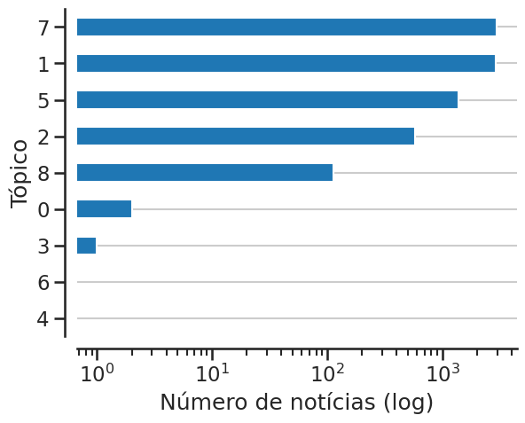

```python
import pandas as pd

topic_counts = news_2016['topic'].value_counts().reindex(range(N_TOKENS), fill_value=0)

with sns.axes_style("ticks"):
    sns.set_context("talk")
    ax = topic_counts.sort_values().plot(kind='barh')
    ax.yaxis.grid(True)
    ax.set_ylabel("Tópico")
    ax.set_xlabel("Número de notícias (log)")
    sns.despine(offset=10)
    ax.set_xscale("log")
```

```python
print(news_2016['topic'].value_counts().sort_index())
# Verifica o número de tópicos
```

```
topic
0       2
1    2907
2     579
3       1
5    1372
7    2969
8     113
Name: count, dtype: int64
```

```python
news_2016.topic
# Verifica a distribuição dos tópicos
```

```
34207    1
34238    7
34245    7
34248    1
34249    1
        ..
94280    5
94295    1
94301    5
94310    5
94314    7
Name: topic, Length: 7943, dtype: int64
```

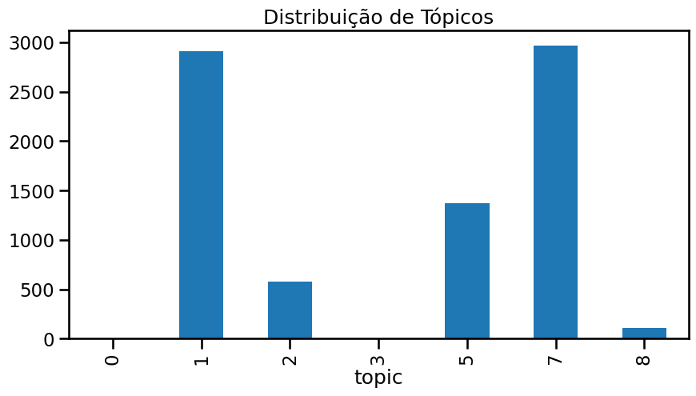

```python
news_2016.topic.value_counts().sort_index().plot(kind='bar', figsize=(10, 5))
plt.title("Distribuição de Tópicos")
```

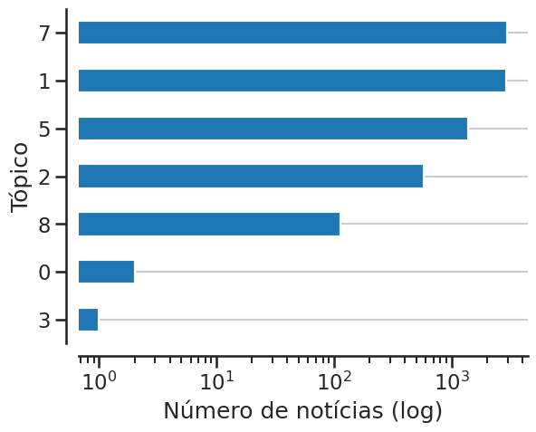

```python
with sns.axes_style("ticks"):
    sns.set_context("talk")
    ax = news_2016['topic'].value_counts().sort_values().plot(kind = 'barh')
    ax.yaxis.grid(True)
    ax.set_ylabel("Tópico")
    ax.set_xlabel("Número de notícias (log)")
    sns.despine(offset = 10)
    ax.set_xscale("log")
```

## Crie uma nuvem de palavra para cada tópico.

Use as colunas `spacy_lemma` e `topic` para essa tarefa.

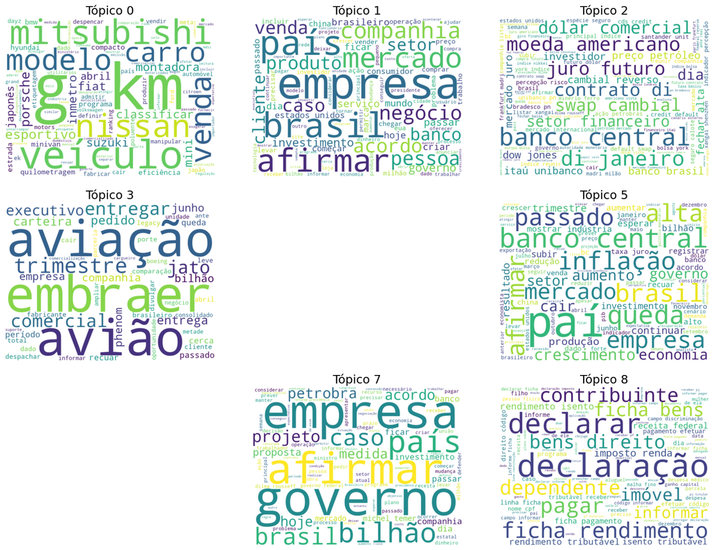

```python
from wordcloud import WordCloud
import matplotlib.pyplot as plt
from itertools import chain

def plot_wordcloud(text: str, ax: plt.Axes) -> plt.Axes:
    """
    Plota a wordcloud para o texto.
    Argumentos:
        - text: string com palavras separadas por espaço
        - ax: o subgráfico (subplot) onde desenhar
    Retorna:
        - ax com a nuvem de palavras desenhada
    """
    wordcloud = WordCloud(
        width=800,
        height=600,
        background_color='white',
        max_words=100,
        colormap='viridis'
    ).generate(text)

    ax.imshow(wordcloud, interpolation='bilinear')
    ax.axis("off")
    return ax

def plot_wordcloud_for_a_topic(topic: int, ax: plt.Axes) -> plt.Axes:
    topic_news = news_2016[news_2016['topic'] == topic]
    list_of_words = chain(*topic_news.spacy_lemma.values.tolist())
    string_complete = ' '.join(list_of_words)
    if not string_complete:
        return None
    return plot_wordcloud(string_complete, ax)

# Criando as 9 nuvens de palavras (3x3)
fig, axis = plt.subplots(3, 3, figsize=(16, 12))

axis_ = axis.flatten()
for idx, ax in enumerate(axis_):
    ax_ = plot_wordcloud_for_a_topic(idx, ax)  # tópicos vão de 0 a 8
    if ax_ is None:
        plt.delaxes(ax)
        continue
    ax.set_title(f"Tópico {idx}")
fig.tight_layout()
plt.show()
```

## Crie uma nuvem de entidades para cada tópico.

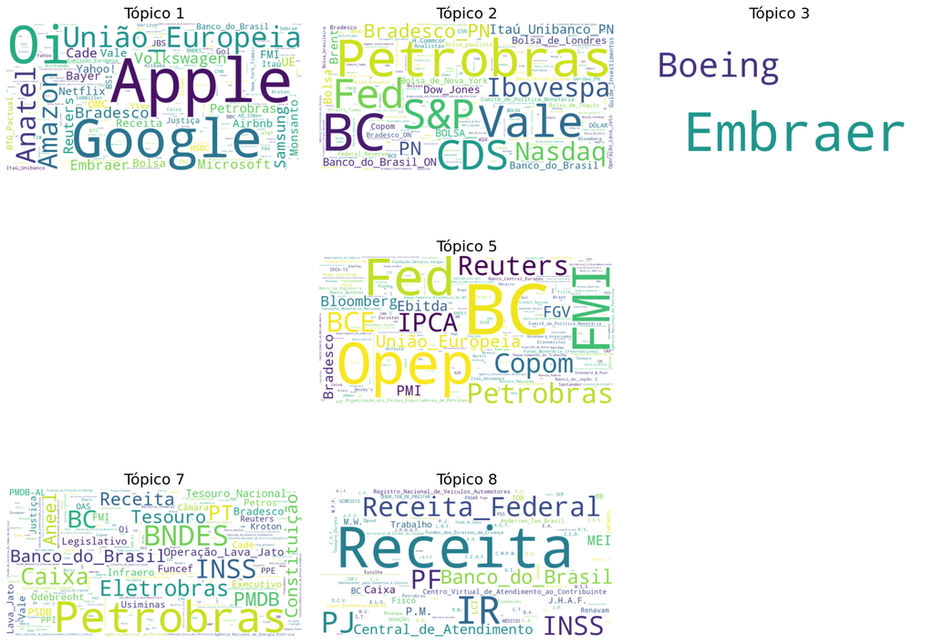

```python
from collections import Counter
def plot_wordcloud_entities_for_a_topic(topic: int, ax: plt.Axes) -> plt.Axes:
    topic_news = news_2016[news_2016['topic'] == topic]

    # Substitui espaços por underlines nas entidades nomeadas
    list_of_docs = topic_news.spacy_ner.apply(lambda l: [w.replace(" ", "_") for w in l])

    # Achata a lista de listas em uma lista única
    list_of_words = list(chain(*list_of_docs))

    if not list_of_words:
        return None

    # Conta frequência de cada entidade
    frequencies = Counter(list_of_words)

    # Gera a nuvem de palavras a partir das frequências
    wordcloud = WordCloud(width=800, height=400, background_color='white').generate_from_frequencies(frequencies)

    ax.imshow(wordcloud, interpolation='bilinear')
    ax.axis("off")
    return ax

fig, axis = plt.subplots(3, 3, figsize=(16, 12))

axis_  = axis.flatten()
for idx, ax in enumerate(axis_):
    ax_ = plot_wordcloud_entities_for_a_topic(idx + 1, ax)
    if ax_ is None:
        plt.delaxes(ax)
        continue
    ax.set_title(f"Tópico {idx + 1}")
fig.tight_layout()
```